# ESM 201 HW 1

### Question 2 Graph $\frac{dN}{Ndt}$ vs. N<sub>t</sub>

#### a. For Each Country Plot $\frac{dN}{Ndt}$ vs. N<sub>t</sub>

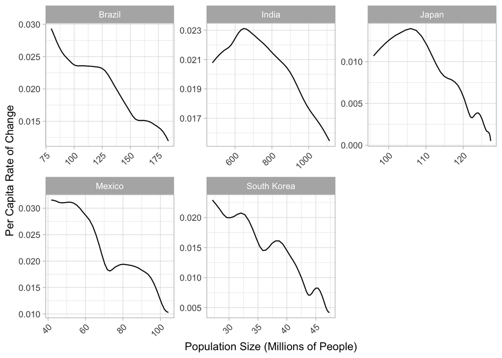

Figure 2: Rate of Population Change by Country. The per capita rate of change of the population is shown against the population size in millions of people for each of the five countries.

#### b. Estimating Carrying Capacity

**Carrying Capacities:**

- **Brazil:**  
  $Population = 2.607*10^8 - 6.392*10^9(\frac{dN}{Ndt})$  
  Carrying capacity (K) = population when $\frac{dN}{Ndt} = 0$  
  $K = 2.607*10^8$
- **South Korea:**  
  $Population = 5.282*10^7 - 1.054*10^9(\frac{dN}{Ndt})$  
  Carrying capacity (K) = population when $\frac{dN}{Ndt} = 0$  
  K = $5.282*10^7$

#### c. Modified Plots

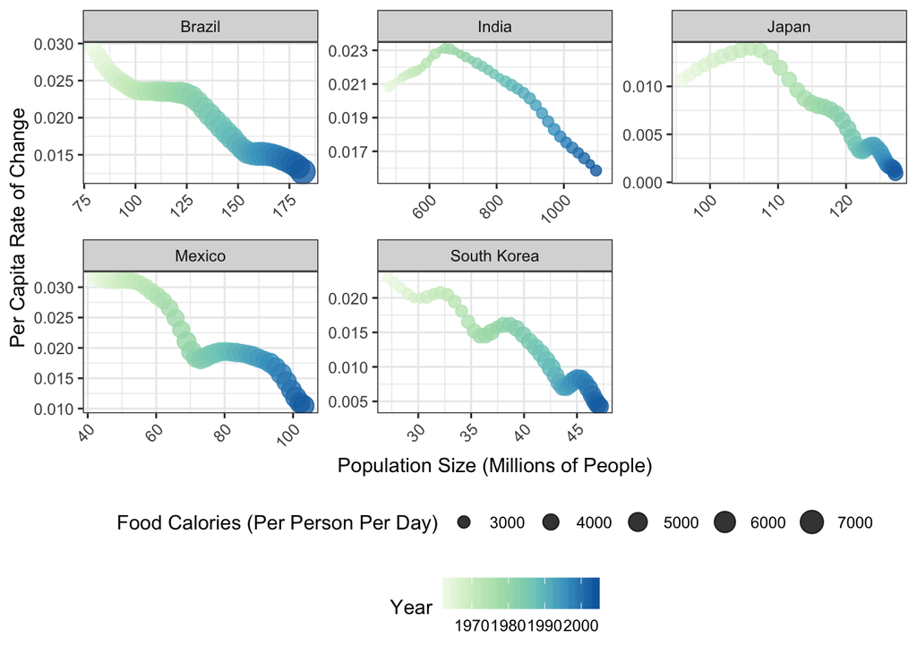

Figure 3: Rate of Population Growth by Country Over Time. The per capita rate of change of the population is shown against the population size in millions of people for each of the five countries. The color of the lines represents the progression through time and size of the points depicts the food calories per person per day.